# Data Transformation With dplyr

Biostat 203B

Author

Dr. Hua Zhou @ UCLA

Published

February 10, 2024

## 1 Preamble

Display machine information for reproducibility.

**R**

**Python**

```python
import IPython
print(IPython.sys_info())
```

```
{'commit_hash': 'dc4369111',
 'commit_source': 'installation',
 'default_encoding': 'utf-8',
 'ipython_path': '/opt/venv/lib/python3.10/site-packages/IPython',
 'ipython_version': '8.19.0',
 'os_name': 'posix',
 'platform': 'Linux-6.6.12-linuxkit-aarch64-with-glibc2.35',
 'sys_executable': '/opt/venv/bin/python',
 'sys_platform': 'linux',
 'sys_version': '3.10.12 (main, Nov 20 2023, 15:14:05) [GCC 11.4.0]'}
```

**Julia**

```julia
using InteractiveUtils
versioninfo()
```

```
Julia Version 1.9.4
Commit 8e5136fa297 (2023-11-14 08:46 UTC)
Build Info:
  Official https://julialang.org/ release
Platform Info:
  OS: Linux (aarch64-linux-gnu)
  CPU: 12 × unknown
  WORD_SIZE: 64
  LIBM: libopenlibm
  LLVM: libLLVM-14.0.6 (ORCJIT, generic)
  Threads: 1 on 12 virtual cores
Environment:
  JULIA_PKGDIR = /opt/julia
  JULIA_DEPOT_PATH = /opt/julia
  LD_LIBRARY_PATH = /usr/local/lib/R/lib:/usr/local/lib:/usr/lib/aarch64-linux-gnu:/usr/lib/jvm/java-11-openjdk-arm64/lib/server:/usr/local/lib/R/lib:/lib:/usr/local/lib:/usr/lib/aarch64-linux-gnu:/usr/lib/jvm/java-11-openjdk-arm64/lib/server
```

Load tidyverse (R), Pandas (Python), and DataFrames.jl (Julia).

**R**

```r
library(tidyverse)
```

**Python**

```python
# Load the pandas library
import pandas as pd
# Load numpy for array manipulation
import numpy as np
```

**Julia**

```julia
using DataFrames, Pipe, StatsBase
```

A typical data science project:

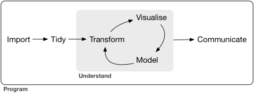

## 2 nycflights13 data

- Available from the nycflights13 package.
- 336,776 flights that departed from New York City in 2013:

**R**

```r
library("nycflights13")
flights
```

```
# A tibble: 336,776 × 19
    year month   day dep_time sched_dep_time dep_delay arr_time sched_arr_time
   <int> <int> <int>    <int>          <int>     <dbl>    <int>          <int>
 1  2013     1     1      517            515         2      830            819
 2  2013     1     1      533            529         4      850            830
 3  2013     1     1      542            540         2      923            850
 4  2013     1     1      544            545        -1     1004           1022
 5  2013     1     1      554            600        -6      812            837
 6  2013     1     1      554            558        -4      740            728
 7  2013     1     1      555            600        -5      913            854
 8  2013     1     1      557            600        -3      709            723
 9  2013     1     1      557            600        -3      838            846
10  2013     1     1      558            600        -2      753            745
# ℹ 336,766 more rows
# ℹ 11 more variables: arr_delay <dbl>, carrier <chr>, flight <int>,
#   tailnum <chr>, origin <chr>, dest <chr>, air_time <dbl>, distance <dbl>,
#   hour <dbl>, minute <dbl>, time_hour <dttm>
```

**Python**

The nycflights13 data is available from the nycflights13 package in Python.

```python
from nycflights13 import flights

flights
```

```
        year  month  day  ...  hour  minute             time_hour
0       2013      1    1  ...     5      15  2013-01-01T10:00:00Z
1       2013      1    1  ...     5      29  2013-01-01T10:00:00Z
2       2013      1    1  ...     5      40  2013-01-01T10:00:00Z
3       2013      1    1  ...     5      45  2013-01-01T10:00:00Z
4       2013      1    1  ...     6       0  2013-01-01T11:00:00Z
...      ...    ...  ...  ...   ...     ...                   ...
336771  2013      9   30  ...    14      55  2013-09-30T18:00:00Z
336772  2013      9   30  ...    22       0  2013-10-01T02:00:00Z
336773  2013      9   30  ...    12      10  2013-09-30T16:00:00Z
336774  2013      9   30  ...    11      59  2013-09-30T15:00:00Z
336775  2013      9   30  ...     8      40  2013-09-30T12:00:00Z

[336776 rows x 19 columns]
```

Note there are some differences of this `flights` data from that in tidyverse. The data types for some variables are different. There are no natural ways in Pandas to hold integer column with missing values; so `dep_time` , `arr_time` are `float64` instead of `int64`.

```python
flights.info()
```

```
<class 'pandas.core.frame.DataFrame'>
RangeIndex: 336776 entries, 0 to 336775
Data columns (total 19 columns):
 #   Column          Non-Null Count   Dtype
---  ------          --------------   -----
 0   year            336776 non-null  int64
 1   month           336776 non-null  int64
 2   day             336776 non-null  int64
 3   dep_time        328521 non-null  float64
 4   sched_dep_time  336776 non-null  int64
 5   dep_delay       328521 non-null  float64
 6   arr_time        328063 non-null  float64
 7   sched_arr_time  336776 non-null  int64
 8   arr_delay       327346 non-null  float64
 9   carrier         336776 non-null  object
 10  flight          336776 non-null  int64
 11  tailnum         334264 non-null  object
 12  origin          336776 non-null  object
 13  dest            336776 non-null  object
 14  air_time        327346 non-null  float64
 15  distance        336776 non-null  int64
 16  hour            336776 non-null  int64
 17  minute          336776 non-null  int64
 18  time_hour       336776 non-null  object
dtypes: float64(5), int64(9), object(5)
memory usage: 48.8+ MB
```

To be more consistent with `nycflights13` in tidyverse, we cast `time_hour` to `datetime` type.

```python
flights['time_hour'] = pd.to_datetime(flights['time_hour'])
```

**Julia**

Let’s use RCall.jl to retrieve the nycflights13 data from R.

```julia
using RCall

R"""
library(nycflights13)
"""
```

```
RObject{StrSxp}
```

```julia
flights = rcopy(R"flights")
```

```
336776×19 DataFrame
    Row │ year   month  day    dep_time  sched_dep_time  dep_delay  arr_time   ⋯
        │ Int64  Int64  Int64  Int64?    Int64           Float64?   Int64?     ⋯
────────┼───────────────────────────────────────────────────────────────────────
      1 │  2013      1      1       517             515        2.0       830   ⋯
      2 │  2013      1      1       533             529        4.0       850
      3 │  2013      1      1       542             540        2.0       923
      4 │  2013      1      1       544             545       -1.0      1004
      5 │  2013      1      1       554             600       -6.0       812   ⋯
      6 │  2013      1      1       554             558       -4.0       740
      7 │  2013      1      1       555             600       -5.0       913
      8 │  2013      1      1       557             600       -3.0       709
   ⋮    │   ⋮      ⋮      ⋮       ⋮            ⋮             ⋮         ⋮       ⋱
 336770 │  2013      9     30      2349            2359      -10.0       325   ⋯
 336771 │  2013      9     30   missing            1842  missing     missing
 336772 │  2013      9     30   missing            1455  missing     missing
 336773 │  2013      9     30   missing            2200  missing     missing
 336774 │  2013      9     30   missing            1210  missing     missing   ⋯
 336775 │  2013      9     30   missing            1159  missing     missing
 336776 │  2013      9     30   missing             840  missing     missing
                                              12 columns and 336761 rows omitted
```

To display more rows or columns:

**R**

- By default, tibble prints the first 10 rows and all columns *that fit on screen*.
- To change number of rows and columns to display:

```r
nycflights13::flights |>
  print(n = 10, width = Inf)
```

```
# A tibble: 336,776 × 19
    year month   day dep_time sched_dep_time dep_delay arr_time sched_arr_time
   <int> <int> <int>    <int>          <int>     <dbl>    <int>          <int>
 1  2013     1     1      517            515         2      830            819
 2  2013     1     1      533            529         4      850            830
 3  2013     1     1      542            540         2      923            850
 4  2013     1     1      544            545        -1     1004           1022
 5  2013     1     1      554            600        -6      812            837
 6  2013     1     1      554            558        -4      740            728
 7  2013     1     1      555            600        -5      913            854
 8  2013     1     1      557            600        -3      709            723
 9  2013     1     1      557            600        -3      838            846
10  2013     1     1      558            600        -2      753            745
   arr_delay carrier flight tailnum origin dest  air_time distance  hour minute
       <dbl> <chr>    <int> <chr>   <chr>  <chr>    <dbl>    <dbl> <dbl>  <dbl>
```

[output cut: 23 more lines]

Here we see the **pipe operator** `|>` pipes the output from previous command to the (first) argument of the next command.

**Python**

- Pandas by default displays 10 rows and limits the number of columns to the display area.
- We can override this behavior by

```python
pd.set_option("display.max_rows", 500)
pd.set_option("display.max_columns", 20)
```

**Julia**

By default DataFrames.jl limits the number of rows and columns when displaying a data frame in a Jupyter Notebook to 25 and 100, respectively. You can override this behavior by changing the values of the `ENV["DATAFRAMES_COLUMNS"]` and `ENV["DATAFRAMES_ROWS"]` variables to hold the maximum number of columns and rows of the output. All columns or rows will be printed if those numbers are equal or lower than 0.

## 3 dplyr basics

- Pick observations (rows) by their values: `filter()`.
- Reorder the rows: `arrange()`.
- Pick variables (columns) by their names: `select()`.
- Create new variables with functions of existing variables: `mutate()`.
- Collapse many values down to a single summary: `summarise()`.

```
verb          meaning
--------------------------------------------
filter()      subset observations (or rows)
arrange()     re-order the observations
distinct()    remove duplicate entries
slice_*()     select rows by position
sample_*()    sample rows
--------------------------------------------
select()      select variables (or columns)
mutate()      add new variables (or columns)
relocate()    move variables (or columns) to new positions
rename()      rename variables (or columns)
--------------------------------------------
group_by()    aggregate
summarise()   reduce to a single row
--------------------------------------------
left_join()   merge two data objects
collect()     force computation and bring data back into R
```

## 4 Manipulate rows (cases)

### 4.1 Filter rows with `filter()`

- Flights on Jan 1st:

**R**

```r
# same as filter(flights, month == 1 & day == 1)
filter(flights, month == 1, day == 1)
```

```
# A tibble: 842 × 19
    year month   day dep_time sched_dep_time dep_delay arr_time sched_arr_time
   <int> <int> <int>    <int>          <int>     <dbl>    <int>          <int>
 1  2013     1     1      517            515         2      830            819
 2  2013     1     1      533            529         4      850            830
 3  2013     1     1      542            540         2      923            850
 4  2013     1     1      544            545        -1     1004           1022
 5  2013     1     1      554            600        -6      812            837
 6  2013     1     1      554            558        -4      740            728
 7  2013     1     1      555            600        -5      913            854
 8  2013     1     1      557            600        -3      709            723
 9  2013     1     1      557            600        -3      838            846
10  2013     1     1      558            600        -2      753            745
# ℹ 832 more rows
# ℹ 11 more variables: arr_delay <dbl>, carrier <chr>, flight <int>,
#   tailnum <chr>, origin <chr>, dest <chr>, air_time <dbl>, distance <dbl>,
#   hour <dbl>, minute <dbl>, time_hour <dttm>
```

**Python**

```python
flights[(flights['month'] == 1) & (flights['day'] == 1)]
```

```
     year  month  day  dep_time  sched_dep_time  dep_delay  arr_time  \
0    2013      1    1     517.0             515        2.0     830.0
1    2013      1    1     533.0             529        4.0     850.0
2    2013      1    1     542.0             540        2.0     923.0
3    2013      1    1     544.0             545       -1.0    1004.0
4    2013      1    1     554.0             600       -6.0     812.0
..    ...    ...  ...       ...             ...        ...       ...
837  2013      1    1    2356.0            2359       -3.0     425.0
838  2013      1    1       NaN            1630        NaN       NaN
839  2013      1    1       NaN            1935        NaN       NaN
840  2013      1    1       NaN            1500        NaN       NaN
841  2013      1    1       NaN             600        NaN       NaN

     sched_arr_time  arr_delay carrier  flight tailnum origin dest  air_time  \
0               819       11.0      UA    1545  N14228    EWR  IAH     227.0
```

[output cut: 25 more lines]

**Julia**

```julia
filter(row -> (row.month == 1) & (row.day == 1), flights)
```

```
842×19 DataFrame
 Row │ year   month  day    dep_time  sched_dep_time  dep_delay  arr_time  sch ⋯
     │ Int64  Int64  Int64  Int64?    Int64           Float64?   Int64?    Int ⋯
─────┼──────────────────────────────────────────────────────────────────────────
   1 │  2013      1      1       517             515        2.0       830      ⋯
   2 │  2013      1      1       533             529        4.0       850
   3 │  2013      1      1       542             540        2.0       923
   4 │  2013      1      1       544             545       -1.0      1004
   5 │  2013      1      1       554             600       -6.0       812      ⋯
   6 │  2013      1      1       554             558       -4.0       740
   7 │  2013      1      1       555             600       -5.0       913
   8 │  2013      1      1       557             600       -3.0       709
  ⋮  │   ⋮      ⋮      ⋮       ⋮            ⋮             ⋮         ⋮          ⋱
 836 │  2013      1      1      2353            2359       -6.0       425      ⋯
 837 │  2013      1      1      2353            2359       -6.0       418
 838 │  2013      1      1      2356            2359       -3.0       425
 839 │  2013      1      1   missing            1630  missing     missing
 840 │  2013      1      1   missing            1935  missing     missing      ⋯
 841 │  2013      1      1   missing            1500  missing     missing
 842 │  2013      1      1   missing             600  missing     missing
                                                 12 columns and 827 rows omitted
```

- Flights in Nov or Dec:

**R**

```r
filter(flights, month == 11 | month == 12)
```

```
# A tibble: 55,403 × 19
    year month   day dep_time sched_dep_time dep_delay arr_time sched_arr_time
   <int> <int> <int>    <int>          <int>     <dbl>    <int>          <int>
 1  2013    11     1        5           2359         6      352            345
 2  2013    11     1       35           2250       105      123           2356
 3  2013    11     1      455            500        -5      641            651
 4  2013    11     1      539            545        -6      856            827
 5  2013    11     1      542            545        -3      831            855
 6  2013    11     1      549            600       -11      912            923
 7  2013    11     1      550            600       -10      705            659
 8  2013    11     1      554            600        -6      659            701
 9  2013    11     1      554            600        -6      826            827
10  2013    11     1      554            600        -6      749            751
# ℹ 55,393 more rows
# ℹ 11 more variables: arr_delay <dbl>, carrier <chr>, flight <int>,
#   tailnum <chr>, origin <chr>, dest <chr>, air_time <dbl>, distance <dbl>,
#   hour <dbl>, minute <dbl>, time_hour <dttm>
```

**Python**

```python
flights[(flights['month'] == 11) | (flights['month'] == 12)]
```

```
        year  month  day  dep_time  sched_dep_time  dep_delay  arr_time  \
55893   2013     11    1       5.0            2359        6.0     352.0
55894   2013     11    1      35.0            2250      105.0     123.0
55895   2013     11    1     455.0             500       -5.0     641.0
55896   2013     11    1     539.0             545       -6.0     856.0
55897   2013     11    1     542.0             545       -3.0     831.0
...      ...    ...  ...       ...             ...        ...       ...
111291  2013     12   31       NaN             705        NaN       NaN
111292  2013     12   31       NaN             825        NaN       NaN
111293  2013     12   31       NaN            1615        NaN       NaN
111294  2013     12   31       NaN             600        NaN       NaN
111295  2013     12   31       NaN             830        NaN       NaN

        sched_arr_time  arr_delay carrier  flight tailnum origin dest  \
55893              345        7.0      B6     745  N568JB    JFK  PSE
```

[output cut: 25 more lines]

**Julia**

```julia
filter(row -> (row.month == 11) | (row.month == 12), flights)
```

```
55403×19 DataFrame
   Row │ year   month  day    dep_time  sched_dep_time  dep_delay  arr_time  s ⋯
       │ Int64  Int64  Int64  Int64?    Int64           Float64?   Int64?    I ⋯
───────┼────────────────────────────────────────────────────────────────────────
     1 │  2013     11      1         5            2359        6.0       352    ⋯
     2 │  2013     11      1        35            2250      105.0       123
     3 │  2013     11      1       455             500       -5.0       641
     4 │  2013     11      1       539             545       -6.0       856
     5 │  2013     11      1       542             545       -3.0       831    ⋯
     6 │  2013     11      1       549             600      -11.0       912
     7 │  2013     11      1       550             600      -10.0       705
     8 │  2013     11      1       554             600       -6.0       659
   ⋮   │   ⋮      ⋮      ⋮       ⋮            ⋮             ⋮         ⋮        ⋱
 55397 │  2013     12     31   missing            1430  missing     missing    ⋯
 55398 │  2013     12     31   missing             855  missing     missing
 55399 │  2013     12     31   missing             705  missing     missing
 55400 │  2013     12     31   missing             825  missing     missing
 55401 │  2013     12     31   missing            1615  missing     missing    ⋯
 55402 │  2013     12     31   missing             600  missing     missing
 55403 │  2013     12     31   missing             830  missing     missing
                                               12 columns and 55388 rows omitted
```

### 4.2 Remove rows with duplicate values

- One row from each month:

**R**

```r
distinct(flights, month, .keep_all = TRUE)
```

```
# A tibble: 12 × 19
    year month   day dep_time sched_dep_time dep_delay arr_time sched_arr_time
   <int> <int> <int>    <int>          <int>     <dbl>    <int>          <int>
 1  2013     1     1      517            515         2      830            819
 2  2013    10     1      447            500       -13      614            648
 3  2013    11     1        5           2359         6      352            345
 4  2013    12     1       13           2359        14      446            445
 5  2013     2     1      456            500        -4      652            648
 6  2013     3     1        4           2159       125      318             56
 7  2013     4     1      454            500        -6      636            640
 8  2013     5     1        9           1655       434      308           2020
 9  2013     6     1        2           2359         3      341            350
10  2013     7     1        1           2029       212      236           2359
11  2013     8     1       12           2130       162      257             14
12  2013     9     1        9           2359        10      343            340
# ℹ 11 more variables: arr_delay <dbl>, carrier <chr>, flight <int>,
#   tailnum <chr>, origin <chr>, dest <chr>, air_time <dbl>, distance <dbl>,
#   hour <dbl>, minute <dbl>, time_hour <dttm>
```

```r
distinct(flights, month)
```

```
# A tibble: 12 × 1
   month
   <int>
 1     1
 2    10
 3    11
 4    12
 5     2
 6     3
 7     4
 8     5
 9     6
10     7
11     8
12     9
```

**Python**

```python
flights.drop_duplicates(subset = ['month'])
```

```
        year  month  day  dep_time  sched_dep_time  dep_delay  arr_time  \
0       2013      1    1     517.0             515        2.0     830.0
27004   2013     10    1     447.0             500      -13.0     614.0
55893   2013     11    1       5.0            2359        6.0     352.0
83161   2013     12    1      13.0            2359       14.0     446.0
111296  2013      2    1     456.0             500       -4.0     652.0
136247  2013      3    1       4.0            2159      125.0     318.0
165081  2013      4    1     454.0             500       -6.0     636.0
193411  2013      5    1       9.0            1655      434.0     308.0
222207  2013      6    1       2.0            2359        3.0     341.0
250450  2013      7    1       1.0            2029      212.0     236.0
279875  2013      8    1      12.0            2130      162.0     257.0
309202  2013      9    1       9.0            2359       10.0     343.0

        sched_arr_time  arr_delay carrier  flight tailnum origin dest  \
```

[output cut: 26 more lines]

**Julia**

```julia
unique(flights, :month)
```

```
12×19 DataFrame
 Row │ year   month  day    dep_time  sched_dep_time  dep_delay  arr_time  sch ⋯
     │ Int64  Int64  Int64  Int64?    Int64           Float64?   Int64?    Int ⋯
─────┼──────────────────────────────────────────────────────────────────────────
   1 │  2013      1      1       517             515        2.0       830      ⋯
   2 │  2013     10      1       447             500      -13.0       614
   3 │  2013     11      1         5            2359        6.0       352
   4 │  2013     12      1        13            2359       14.0       446
   5 │  2013      2      1       456             500       -4.0       652      ⋯
   6 │  2013      3      1         4            2159      125.0       318
   7 │  2013      4      1       454             500       -6.0       636
   8 │  2013      5      1         9            1655      434.0       308
   9 │  2013      6      1         2            2359        3.0       341      ⋯
  10 │  2013      7      1         1            2029      212.0       236
  11 │  2013      8      1        12            2130      162.0       257
  12 │  2013      9      1         9            2359       10.0       343
                                                              12 columns omitted
```

### 4.3 Sample rows

**R**

- Randomly select `n` rows:

```r
sample_n(flights, 10, replace = TRUE)
```

```
# A tibble: 10 × 19
    year month   day dep_time sched_dep_time dep_delay arr_time sched_arr_time
   <int> <int> <int>    <int>          <int>     <dbl>    <int>          <int>
 1  2013     2     1     1812           1815        -3     2016           2032
 2  2013     6     7     2336           2245        51      120           2357
 3  2013    11     4     2027           2025         2     2240           2242
 4  2013    12    21     1220           1207        13     1356           1348
 5  2013     3    13     1103           1101         2     1408           1433
 6  2013    10     8     1049           1059       -10     1221           1242
 7  2013    11    23     1657           1700        -3     2009           2011
 8  2013     7    21      924            829        55     1133           1004
 9  2013     9     9     1208           1205         3     1357           1418
10  2013    12    24     2130           2130         0     2353           2359
# ℹ 11 more variables: arr_delay <dbl>, carrier <chr>, flight <int>,
#   tailnum <chr>, origin <chr>, dest <chr>, air_time <dbl>, distance <dbl>,
#   hour <dbl>, minute <dbl>, time_hour <dttm>
```

- Randomly select fraction of rows:

```r
sample_frac(flights, 0.1, replace = TRUE)
```

```
# A tibble: 33,678 × 19
    year month   day dep_time sched_dep_time dep_delay arr_time sched_arr_time
   <int> <int> <int>    <int>          <int>     <dbl>    <int>          <int>
 1  2013     8    28     1935           1935         0     2222           2237
 2  2013    12    20     1443           1445        -2     1755           1813
 3  2013     6     1     1614           1540        34     1800           1733
 4  2013     9    10     1704           1700         4     1835           1817
 5  2013     3    21     1421           1422        -1     1703           1715
 6  2013    10    27     1055           1030        25     1335           1324
 7  2013     8    30     1654           1700        -6     1849           1923
 8  2013     1    22      955           1000        -5     1256           1254
 9  2013    11    15     1825           1830        -5     2131           2138
10  2013     3    20     1643           1646        -3     1735           1751
# ℹ 33,668 more rows
# ℹ 11 more variables: arr_delay <dbl>, carrier <chr>, flight <int>,
#   tailnum <chr>, origin <chr>, dest <chr>, air_time <dbl>, distance <dbl>,
#   hour <dbl>, minute <dbl>, time_hour <dttm>
```

**Python**

Sample `n=10` rows.

```python
flights.sample(n = 10, axis = 0, replace = True)
```

```
        year  month  day  dep_time  sched_dep_time  dep_delay  arr_time  \
19713   2013      1   23    1631.0            1635       -4.0    1853.0
37769   2013     10   12    1228.0            1235       -7.0    1414.0
111938  2013      2    1    1701.0            1708       -7.0    2009.0
56981   2013     11    2     755.0             800       -5.0    1057.0
73845   2013     11   20    1212.0            1220       -8.0    1356.0
21628   2013      1   25    1801.0            1810       -9.0    2152.0
15695   2013      1   18    1855.0            1859       -4.0    2157.0
111914  2013      2    1    1645.0            1645        0.0    1847.0
232371  2013      6   11    2358.0            2359       -1.0     345.0
50745   2013     10   26    1152.0            1200       -8.0    1439.0

        sched_arr_time  arr_delay carrier  flight tailnum origin dest  \
19713             1907      -14.0      EV    4705  N13989    EWR  ATL
37769             1426      -12.0      EV    4649  N16954    EWR  CLT
```

[output cut: 20 more lines]

Sample 10% rows:

```python
flights.sample(frac = 0.1, replace = True)
```

```
        year  month  day  dep_time  sched_dep_time  dep_delay  arr_time  \
147407  2013      3   13     608.0             610       -2.0     921.0
241844  2013      6   21    1911.0            1900       11.0    2202.0
55796   2013     10   31    1943.0            1935        8.0    2210.0
278900  2013      7   31     559.0             600       -1.0     735.0
303174  2013      8   25    1408.0            1411       -3.0    1525.0
...      ...    ...  ...       ...             ...        ...       ...
278008  2013      7   30     730.0             730        0.0    1027.0
303850  2013      8   26     810.0             815       -5.0    1012.0
274960  2013      7   26    1911.0            1915       -4.0    2227.0
34148   2013     10    8    1552.0            1555       -3.0    1751.0
149781  2013      3   15    1350.0            1329       21.0    1535.0

        sched_arr_time  arr_delay carrier  flight tailnum origin dest  \
147407             915        6.0      AA    1837  N3HBAA    LGA  MIA
```

[output cut: 25 more lines]

**Julia**

I’m not sure whether there’s a native function in DataFrames.jl for sampling.

Sample 10 rows:

```julia
rowidx = StatsBase.sample(1:nrow(flights), 10, replace = true);
flights[rowidx, :]
```

```
10×19 DataFrame
 Row │ year   month  day    dep_time  sched_dep_time  dep_delay  arr_time  sch ⋯
     │ Int64  Int64  Int64  Int64?    Int64           Float64?   Int64?    Int ⋯
─────┼──────────────────────────────────────────────────────────────────────────
   1 │  2013      9      4      2030            2034       -4.0      2134      ⋯
   2 │  2013      5      6       849             900      -11.0      1021
   3 │  2013      9     22      1201            1206       -5.0      1444
   4 │  2013      7     31      1135             829      186.0      1300
   5 │  2013      7     10      1204            1209       -5.0      1401      ⋯
   6 │  2013      9     18       857             900       -3.0      1210
   7 │  2013      7      7      1827            1830       -3.0      2136
   8 │  2013     10      4      1642            1645       -3.0      1756
   9 │  2013      6     19      1522            1527       -5.0      1646      ⋯
  10 │  2013      3     21      1310            1200       70.0      1427
                                                              12 columns omitted
```

Sample 10% rows:

```julia
rowidx = StatsBase.sample(
  1:nrow(flights),
  round(Int, nrow(flights) * 0.1),
  replace = true);
flights[rowidx, :]
```

```
33678×19 DataFrame
   Row │ year   month  day    dep_time  sched_dep_time  dep_delay  arr_time  s ⋯
       │ Int64  Int64  Int64  Int64?    Int64           Float64?   Int64?    I ⋯
───────┼────────────────────────────────────────────────────────────────────────
     1 │  2013     11     26       858             900       -2.0      1128    ⋯
     2 │  2013      1     11      1344            1350       -6.0      1558
     3 │  2013      2     23      1127            1059       28.0      1418
     4 │  2013     12      5       553             600       -7.0       919
     5 │  2013      5     25      1339            1340       -1.0      1600    ⋯
     6 │  2013      9     15      1324            1330       -6.0      1545
     7 │  2013      3     24      1911            1810       61.0      2250
     8 │  2013      4      6       713             715       -2.0       902
   ⋮   │   ⋮      ⋮      ⋮       ⋮            ⋮             ⋮         ⋮        ⋱
 33672 │  2013      7     12      2038            1935       63.0      2357    ⋯
 33673 │  2013      8     26      2117            2100       17.0      2254
 33674 │  2013      5     13       731             735       -4.0      1027
 33675 │  2013      7     11       946             825       81.0      1149
 33676 │  2013      7      5       650             655       -5.0       917    ⋯
 33677 │  2013      8     21      1214            1219       -5.0      1405
 33678 │  2013      1      6       954             955       -1.0      1233
                                               12 columns and 33663 rows omitted
```

### 4.4 Select rows by position

**R**

- Select rows by position:

```r
slice(flights, 1:5)
```

```
# A tibble: 5 × 19
   year month   day dep_time sched_dep_time dep_delay arr_time sched_arr_time
  <int> <int> <int>    <int>          <int>     <dbl>    <int>          <int>
1  2013     1     1      517            515         2      830            819
2  2013     1     1      533            529         4      850            830
3  2013     1     1      542            540         2      923            850
4  2013     1     1      544            545        -1     1004           1022
5  2013     1     1      554            600        -6      812            837
# ℹ 11 more variables: arr_delay <dbl>, carrier <chr>, flight <int>,
#   tailnum <chr>, origin <chr>, dest <chr>, air_time <dbl>, distance <dbl>,
#   hour <dbl>, minute <dbl>, time_hour <dttm>
```

- First rows:

```r
slice_head(flights, n = 5)
```

```
# A tibble: 5 × 19
   year month   day dep_time sched_dep_time dep_delay arr_time sched_arr_time
  <int> <int> <int>    <int>          <int>     <dbl>    <int>          <int>
1  2013     1     1      517            515         2      830            819
2  2013     1     1      533            529         4      850            830
3  2013     1     1      542            540         2      923            850
4  2013     1     1      544            545        -1     1004           1022
5  2013     1     1      554            600        -6      812            837
# ℹ 11 more variables: arr_delay <dbl>, carrier <chr>, flight <int>,
#   tailnum <chr>, origin <chr>, dest <chr>, air_time <dbl>, distance <dbl>,
#   hour <dbl>, minute <dbl>, time_hour <dttm>
```

- Last rows:

```r
slice_tail(flights, n = 5)
```

```
# A tibble: 5 × 19
   year month   day dep_time sched_dep_time dep_delay arr_time sched_arr_time
  <int> <int> <int>    <int>          <int>     <dbl>    <int>          <int>
1  2013     9    30       NA           1455        NA       NA           1634
2  2013     9    30       NA           2200        NA       NA           2312
3  2013     9    30       NA           1210        NA       NA           1330
4  2013     9    30       NA           1159        NA       NA           1344
5  2013     9    30       NA            840        NA       NA           1020
# ℹ 11 more variables: arr_delay <dbl>, carrier <chr>, flight <int>,
#   tailnum <chr>, origin <chr>, dest <chr>, air_time <dbl>, distance <dbl>,
#   hour <dbl>, minute <dbl>, time_hour <dttm>
```

- Top `n` rows with the highest values:

```r
# deprecated: top_n(flights, 5, wt = time_hour)
# This function is quick
slice_max(flights, n = 5, order_by = time_hour) |>
  print(width = Inf)
```

```
# A tibble: 5 × 19
   year month   day dep_time sched_dep_time dep_delay arr_time sched_arr_time
  <int> <int> <int>    <int>          <int>     <dbl>    <int>          <int>
1  2013    12    31       13           2359        14      439            437
2  2013    12    31       18           2359        19      449            444
3  2013    12    31     2328           2330        -2      412            409
4  2013    12    31     2355           2359        -4      430            440
5  2013    12    31     2356           2359        -3      436            445
  arr_delay carrier flight tailnum origin dest  air_time distance  hour minute
      <dbl> <chr>    <int> <chr>   <chr>  <chr>    <dbl>    <dbl> <dbl>  <dbl>
1         2 B6         839 N566JB  JFK    BQN        189     1576    23     59
2         5 DL         412 N713TW  JFK    SJU        192     1598    23     59
3         3 B6        1389 N651JB  EWR    SJU        198     1608    23     30
4       -10 B6        1503 N509JB  JFK    SJU        195     1598    23     59
5        -9 B6         745 N665JB  JFK    PSE        200     1617    23     59
  time_hour
  <dttm>
1 2013-12-31 23:00:00
2 2013-12-31 23:00:00
3 2013-12-31 23:00:00
4 2013-12-31 23:00:00
5 2013-12-31 23:00:00
```

- Bottom `n` rows with lowest values:

```r
# same as slice_max(flights, n = 5, order_by = desc(time_hour))
slice_min(flights, n = 5, order_by = time_hour) |>
  print(width = Inf)
```

```
# A tibble: 6 × 19
   year month   day dep_time sched_dep_time dep_delay arr_time sched_arr_time
  <int> <int> <int>    <int>          <int>     <dbl>    <int>          <int>
1  2013     1     1      517            515         2      830            819
2  2013     1     1      533            529         4      850            830
3  2013     1     1      542            540         2      923            850
4  2013     1     1      544            545        -1     1004           1022
5  2013     1     1      554            558        -4      740            728
6  2013     1     1      559            559         0      702            706
  arr_delay carrier flight tailnum origin dest  air_time distance  hour minute
      <dbl> <chr>    <int> <chr>   <chr>  <chr>    <dbl>    <dbl> <dbl>  <dbl>
1        11 UA        1545 N14228  EWR    IAH        227     1400     5     15
2        20 UA        1714 N24211  LGA    IAH        227     1416     5     29
3        33 AA        1141 N619AA  JFK    MIA        160     1089     5     40
4       -18 B6         725 N804JB  JFK    BQN        183     1576     5     45
5        12 UA        1696 N39463  EWR    ORD        150      719     5     58
6        -4 B6        1806 N708JB  JFK    BOS         44      187     5     59
  time_hour
  <dttm>
1 2013-01-01 05:00:00
2 2013-01-01 05:00:00
3 2013-01-01 05:00:00
4 2013-01-01 05:00:00
5 2013-01-01 05:00:00
6 2013-01-01 05:00:00
```

- `slice_*` verbs apply to groups for grouped tibbles.

**Python**

- Select rows by position:

```python
flights.iloc[range(0, 5)]
```

```
   year  month  day  dep_time  sched_dep_time  dep_delay  arr_time  \
0  2013      1    1     517.0             515        2.0     830.0
1  2013      1    1     533.0             529        4.0     850.0
2  2013      1    1     542.0             540        2.0     923.0
3  2013      1    1     544.0             545       -1.0    1004.0
4  2013      1    1     554.0             600       -6.0     812.0

   sched_arr_time  arr_delay carrier  flight tailnum origin dest  air_time  \
0             819       11.0      UA    1545  N14228    EWR  IAH     227.0
1             830       20.0      UA    1714  N24211    LGA  IAH     227.0
2             850       33.0      AA    1141  N619AA    JFK  MIA     160.0
3            1022      -18.0      B6     725  N804JB    JFK  BQN     183.0
4             837      -25.0      DL     461  N668DN    LGA  ATL     116.0

   distance  hour  minute                 time_hour
0      1400     5      15 2013-01-01 10:00:00+00:00
1      1416     5      29 2013-01-01 10:00:00+00:00
2      1089     5      40 2013-01-01 10:00:00+00:00
3      1576     5      45 2013-01-01 10:00:00+00:00
4       762     6       0 2013-01-01 11:00:00+00:00
```

- First rows:

```python
flights.head(5)
```

```
   year  month  day  dep_time  sched_dep_time  dep_delay  arr_time  \
0  2013      1    1     517.0             515        2.0     830.0
1  2013      1    1     533.0             529        4.0     850.0
2  2013      1    1     542.0             540        2.0     923.0
3  2013      1    1     544.0             545       -1.0    1004.0
4  2013      1    1     554.0             600       -6.0     812.0

   sched_arr_time  arr_delay carrier  flight tailnum origin dest  air_time  \
0             819       11.0      UA    1545  N14228    EWR  IAH     227.0
1             830       20.0      UA    1714  N24211    LGA  IAH     227.0
2             850       33.0      AA    1141  N619AA    JFK  MIA     160.0
3            1022      -18.0      B6     725  N804JB    JFK  BQN     183.0
4             837      -25.0      DL     461  N668DN    LGA  ATL     116.0

   distance  hour  minute                 time_hour
0      1400     5      15 2013-01-01 10:00:00+00:00
1      1416     5      29 2013-01-01 10:00:00+00:00
2      1089     5      40 2013-01-01 10:00:00+00:00
3      1576     5      45 2013-01-01 10:00:00+00:00
4       762     6       0 2013-01-01 11:00:00+00:00
```

- Last rows:

```python
flights.tail(5)
```

```
        year  month  day  dep_time  sched_dep_time  dep_delay  arr_time  \
336771  2013      9   30       NaN            1455        NaN       NaN
336772  2013      9   30       NaN            2200        NaN       NaN
336773  2013      9   30       NaN            1210        NaN       NaN
336774  2013      9   30       NaN            1159        NaN       NaN
336775  2013      9   30       NaN             840        NaN       NaN

        sched_arr_time  arr_delay carrier  flight tailnum origin dest  \
336771            1634        NaN      9E    3393     NaN    JFK  DCA
336772            2312        NaN      9E    3525     NaN    LGA  SYR
336773            1330        NaN      MQ    3461  N535MQ    LGA  BNA
336774            1344        NaN      MQ    3572  N511MQ    LGA  CLE
336775            1020        NaN      MQ    3531  N839MQ    LGA  RDU

        air_time  distance  hour  minute                 time_hour
336771       NaN       213    14      55 2013-09-30 18:00:00+00:00
336772       NaN       198    22       0 2013-10-01 02:00:00+00:00
336773       NaN       764    12      10 2013-09-30 16:00:00+00:00
336774       NaN       419    11      59 2013-09-30 15:00:00+00:00
336775       NaN       431     8      40 2013-09-30 12:00:00+00:00
```

- Top `n` rows with the highest values:

```python
flights.nlargest(n = 5, columns = 'time_hour')
```

```
        year  month  day  dep_time  sched_dep_time  dep_delay  arr_time  \
110520  2013     12   31      13.0            2359       14.0     439.0
110521  2013     12   31      18.0            2359       19.0     449.0
111276  2013     12   31    2328.0            2330       -2.0     412.0
111278  2013     12   31    2355.0            2359       -4.0     430.0
111279  2013     12   31    2356.0            2359       -3.0     436.0

        sched_arr_time  arr_delay carrier  flight tailnum origin dest  \
110520             437        2.0      B6     839  N566JB    JFK  BQN
110521             444        5.0      DL     412  N713TW    JFK  SJU
111276             409        3.0      B6    1389  N651JB    EWR  SJU
111278             440      -10.0      B6    1503  N509JB    JFK  SJU
111279             445       -9.0      B6     745  N665JB    JFK  PSE

        air_time  distance  hour  minute                 time_hour
110520     189.0      1576    23      59 2014-01-01 04:00:00+00:00
110521     192.0      1598    23      59 2014-01-01 04:00:00+00:00
111276     198.0      1608    23      30 2014-01-01 04:00:00+00:00
111278     195.0      1598    23      59 2014-01-01 04:00:00+00:00
111279     200.0      1617    23      59 2014-01-01 04:00:00+00:00
```

- Bottom `n` rows with lowest values:

```python
flights.nsmallest(n = 5, columns = 'time_hour')
```

```
   year  month  day  dep_time  sched_dep_time  dep_delay  arr_time  \
0  2013      1    1     517.0             515        2.0     830.0
1  2013      1    1     533.0             529        4.0     850.0
2  2013      1    1     542.0             540        2.0     923.0
3  2013      1    1     544.0             545       -1.0    1004.0
5  2013      1    1     554.0             558       -4.0     740.0

   sched_arr_time  arr_delay carrier  flight tailnum origin dest  air_time  \
0             819       11.0      UA    1545  N14228    EWR  IAH     227.0
1             830       20.0      UA    1714  N24211    LGA  IAH     227.0
2             850       33.0      AA    1141  N619AA    JFK  MIA     160.0
3            1022      -18.0      B6     725  N804JB    JFK  BQN     183.0
5             728       12.0      UA    1696  N39463    EWR  ORD     150.0

   distance  hour  minute                 time_hour
0      1400     5      15 2013-01-01 10:00:00+00:00
1      1416     5      29 2013-01-01 10:00:00+00:00
2      1089     5      40 2013-01-01 10:00:00+00:00
3      1576     5      45 2013-01-01 10:00:00+00:00
5       719     5      58 2013-01-01 10:00:00+00:00
```

I don’t think `nlargest` and `nsmallest` apply to grouped DataFrame. But I may be wrong.

**Julia**

- Select rows by position:

```julia
flights[1:5, :]
```

```
5×19 DataFrame
 Row │ year   month  day    dep_time  sched_dep_time  dep_delay  arr_time  sch ⋯
     │ Int64  Int64  Int64  Int64?    Int64           Float64?   Int64?    Int ⋯
─────┼──────────────────────────────────────────────────────────────────────────
   1 │  2013      1      1       517             515        2.0       830      ⋯
   2 │  2013      1      1       533             529        4.0       850
   3 │  2013      1      1       542             540        2.0       923
   4 │  2013      1      1       544             545       -1.0      1004
   5 │  2013      1      1       554             600       -6.0       812      ⋯
                                                              12 columns omitted
```

- First rows:

```julia
first(flights, 5)
```

```
5×19 DataFrame
 Row │ year   month  day    dep_time  sched_dep_time  dep_delay  arr_time  sch ⋯
     │ Int64  Int64  Int64  Int64?    Int64           Float64?   Int64?    Int ⋯
─────┼──────────────────────────────────────────────────────────────────────────
   1 │  2013      1      1       517             515        2.0       830      ⋯
   2 │  2013      1      1       533             529        4.0       850
   3 │  2013      1      1       542             540        2.0       923
   4 │  2013      1      1       544             545       -1.0      1004
   5 │  2013      1      1       554             600       -6.0       812      ⋯
                                                              12 columns omitted
```

- Last rows:

```julia
last(flights, 5)
```

```
5×19 DataFrame
 Row │ year   month  day    dep_time  sched_dep_time  dep_delay  arr_time  sch ⋯
     │ Int64  Int64  Int64  Int64?    Int64           Float64?   Int64?    Int ⋯
─────┼──────────────────────────────────────────────────────────────────────────
   1 │  2013      9     30   missing            1455    missing   missing      ⋯
   2 │  2013      9     30   missing            2200    missing   missing
   3 │  2013      9     30   missing            1210    missing   missing
   4 │  2013      9     30   missing            1159    missing   missing
   5 │  2013      9     30   missing             840    missing   missing      ⋯
                                                              12 columns omitted
```

- Top `n` rows with the highest values:

```julia
last(sort(flights, [:time_hour]), 5)
```

```
5×19 DataFrame
 Row │ year   month  day    dep_time  sched_dep_time  dep_delay  arr_time  sch ⋯
     │ Int64  Int64  Int64  Int64?    Int64           Float64?   Int64?    Int ⋯
─────┼──────────────────────────────────────────────────────────────────────────
   1 │  2013     12     31        13            2359       14.0       439      ⋯
   2 │  2013     12     31        18            2359       19.0       449
   3 │  2013     12     31      2328            2330       -2.0       412
   4 │  2013     12     31      2355            2359       -4.0       430
   5 │  2013     12     31      2356            2359       -3.0       436      ⋯
                                                              12 columns omitted
```

- Bottom `n` rows with lowest values:

```julia
first(sort(flights, [:time_hour]), 5)
```

```
5×19 DataFrame
 Row │ year   month  day    dep_time  sched_dep_time  dep_delay  arr_time  sch ⋯
     │ Int64  Int64  Int64  Int64?    Int64           Float64?   Int64?    Int ⋯
─────┼──────────────────────────────────────────────────────────────────────────
   1 │  2013      1      1       517             515        2.0       830      ⋯
   2 │  2013      1      1       533             529        4.0       850
   3 │  2013      1      1       542             540        2.0       923
   4 │  2013      1      1       544             545       -1.0      1004
   5 │  2013      1      1       554             558       -4.0       740      ⋯
                                                              12 columns omitted
```

### 4.5 Arrange rows with `arrange()`

**R**

- Sort in ascending order:

```r
arrange(flights, year, month, day)
```

```
# A tibble: 336,776 × 19
    year month   day dep_time sched_dep_time dep_delay arr_time sched_arr_time
   <int> <int> <int>    <int>          <int>     <dbl>    <int>          <int>
 1  2013     1     1      517            515         2      830            819
 2  2013     1     1      533            529         4      850            830
 3  2013     1     1      542            540         2      923            850
 4  2013     1     1      544            545        -1     1004           1022
 5  2013     1     1      554            600        -6      812            837
 6  2013     1     1      554            558        -4      740            728
 7  2013     1     1      555            600        -5      913            854
 8  2013     1     1      557            600        -3      709            723
 9  2013     1     1      557            600        -3      838            846
10  2013     1     1      558            600        -2      753            745
# ℹ 336,766 more rows
# ℹ 11 more variables: arr_delay <dbl>, carrier <chr>, flight <int>,
#   tailnum <chr>, origin <chr>, dest <chr>, air_time <dbl>, distance <dbl>,
#   hour <dbl>, minute <dbl>, time_hour <dttm>
```

Note input order matters!

```r
arrange(flights, day, month, year)
```

```
# A tibble: 336,776 × 19
    year month   day dep_time sched_dep_time dep_delay arr_time sched_arr_time
   <int> <int> <int>    <int>          <int>     <dbl>    <int>          <int>
 1  2013     1     1      517            515         2      830            819
 2  2013     1     1      533            529         4      850            830
 3  2013     1     1      542            540         2      923            850
 4  2013     1     1      544            545        -1     1004           1022
 5  2013     1     1      554            600        -6      812            837
 6  2013     1     1      554            558        -4      740            728
 7  2013     1     1      555            600        -5      913            854
 8  2013     1     1      557            600        -3      709            723
 9  2013     1     1      557            600        -3      838            846
10  2013     1     1      558            600        -2      753            745
# ℹ 336,766 more rows
# ℹ 11 more variables: arr_delay <dbl>, carrier <chr>, flight <int>,
#   tailnum <chr>, origin <chr>, dest <chr>, air_time <dbl>, distance <dbl>,
#   hour <dbl>, minute <dbl>, time_hour <dttm>
```

- Sort in descending order:

```r
arrange(flights, desc(arr_delay)) |>
  print(width = Inf)
```

```
# A tibble: 336,776 × 19
    year month   day dep_time sched_dep_time dep_delay arr_time sched_arr_time
   <int> <int> <int>    <int>          <int>     <dbl>    <int>          <int>
 1  2013     1     9      641            900      1301     1242           1530
 2  2013     6    15     1432           1935      1137     1607           2120
 3  2013     1    10     1121           1635      1126     1239           1810
 4  2013     9    20     1139           1845      1014     1457           2210
 5  2013     7    22      845           1600      1005     1044           1815
 6  2013     4    10     1100           1900       960     1342           2211
 7  2013     3    17     2321            810       911      135           1020
 8  2013     7    22     2257            759       898      121           1026
 9  2013    12     5      756           1700       896     1058           2020
10  2013     5     3     1133           2055       878     1250           2215
   arr_delay carrier flight tailnum origin dest  air_time distance  hour minute
       <dbl> <chr>    <int> <chr>   <chr>  <chr>    <dbl>    <dbl> <dbl>  <dbl>
```

[output cut: 23 more lines]

- By default, `arrange` ignores grouping in grouped tibbles. Set `.by_group = TRUE` to arrange within each group.

```r
# What are the worst delays in each month?
flights |>
  group_by(month) |>
  arrange(desc(arr_delay), .by_group = TRUE) |>
  print(width = Inf)
```

```
# A tibble: 336,776 × 19
# Groups:   month [12]
    year month   day dep_time sched_dep_time dep_delay arr_time sched_arr_time
   <int> <int> <int>    <int>          <int>     <dbl>    <int>          <int>
 1  2013     1     9      641            900      1301     1242           1530
 2  2013     1    10     1121           1635      1126     1239           1810
 3  2013     1     1      848           1835       853     1001           1950
 4  2013     1    13     1809            810       599     2054           1042
 5  2013     1    16     1622            800       502     1911           1054
 6  2013     1    23     1551            753       478     1812           1006
 7  2013     1     1     2343           1724       379      314           1938
 8  2013     1    10     1525            900       385     1713           1039
 9  2013     1    25       15           1815       360      208           1958
10  2013     1     2     1607           1030       337     2003           1355
   arr_delay carrier flight tailnum origin dest  air_time distance  hour minute
```

[output cut: 24 more lines]

**Python**

- Sort in ascending order:

```python
flights.sort_values(by = 'arr_delay')
```

```
        year  month  day  dep_time  sched_dep_time  dep_delay  arr_time  \
199668  2013      5    7    1715.0            1729      -14.0    1944.0
211124  2013      5   20     719.0             735      -16.0     951.0
198763  2013      5    6    1826.0            1830       -4.0    2045.0
195236  2013      5    2    1947.0            1949       -2.0    2209.0
196935  2013      5    4    1816.0            1820       -4.0    2017.0
...      ...    ...  ...       ...             ...        ...       ...
336771  2013      9   30       NaN            1455        NaN       NaN
336772  2013      9   30       NaN            2200        NaN       NaN
336773  2013      9   30       NaN            1210        NaN       NaN
336774  2013      9   30       NaN            1159        NaN       NaN
336775  2013      9   30       NaN             840        NaN       NaN

        sched_arr_time  arr_delay carrier  flight tailnum origin dest  \
199668            2110      -86.0      VX     193  N843VA    EWR  SFO
```

[output cut: 25 more lines]

- Sort in descending order:

```python
flights.sort_values(
  by = 'arr_delay',
  ascending = False
  )
```

```
        year  month  day  dep_time  sched_dep_time  dep_delay  arr_time  \
7072    2013      1    9     641.0             900     1301.0    1242.0
235778  2013      6   15    1432.0            1935     1137.0    1607.0
8239    2013      1   10    1121.0            1635     1126.0    1239.0
327043  2013      9   20    1139.0            1845     1014.0    1457.0
270376  2013      7   22     845.0            1600     1005.0    1044.0
...      ...    ...  ...       ...             ...        ...       ...
336771  2013      9   30       NaN            1455        NaN       NaN
336772  2013      9   30       NaN            2200        NaN       NaN
336773  2013      9   30       NaN            1210        NaN       NaN
336774  2013      9   30       NaN            1159        NaN       NaN
336775  2013      9   30       NaN             840        NaN       NaN

        sched_arr_time  arr_delay carrier  flight tailnum origin dest  \
7072              1530     1272.0      HA      51  N384HA    JFK  HNL
```

[output cut: 25 more lines]

- To sort within groups (`month`)

```python
flights.sort_values(
  by = ['month', 'arr_delay'],
  ascending = [True, False]
  )
```

```
        year  month  day  dep_time  sched_dep_time  dep_delay  arr_time  \
7072    2013      1    9     641.0             900     1301.0    1242.0
8239    2013      1   10    1121.0            1635     1126.0    1239.0
151     2013      1    1     848.0            1835      853.0    1001.0
11063   2013      1   13    1809.0             810      599.0    2054.0
13654   2013      1   16    1622.0             800      502.0    1911.0
...      ...    ...  ...       ...             ...        ...       ...
111291  2013     12   31       NaN             705        NaN       NaN
111292  2013     12   31       NaN             825        NaN       NaN
111293  2013     12   31       NaN            1615        NaN       NaN
111294  2013     12   31       NaN             600        NaN       NaN
111295  2013     12   31       NaN             830        NaN       NaN

        sched_arr_time  arr_delay carrier  flight tailnum origin dest  \
7072              1530     1272.0      HA      51  N384HA    JFK  HNL
```

[output cut: 25 more lines]

**Julia**

Sort in ascending order:

```julia
sort(flights, [:arr_delay])
```

```
336776×19 DataFrame
    Row │ year   month  day    dep_time  sched_dep_time  dep_delay  arr_time   ⋯
        │ Int64  Int64  Int64  Int64?    Int64           Float64?   Int64?     ⋯
────────┼───────────────────────────────────────────────────────────────────────
      1 │  2013      5      7      1715            1729      -14.0      1944   ⋯
      2 │  2013      5     20       719             735      -16.0       951
      3 │  2013      5      2      1947            1949       -2.0      2209
      4 │  2013      5      6      1826            1830       -4.0      2045
      5 │  2013      5      4      1816            1820       -4.0      2017   ⋯
      6 │  2013      5      2      1926            1929       -3.0      2157
      7 │  2013      5      6      1753            1755       -2.0      2004
      8 │  2013      5      7      2054            2055       -1.0      2317
   ⋮    │   ⋮      ⋮      ⋮       ⋮            ⋮             ⋮         ⋮       ⋱
 336770 │  2013      9     30       559             600       -1.0   missing   ⋯
 336771 │  2013      9     30   missing            1842  missing     missing
 336772 │  2013      9     30   missing            1455  missing     missing
 336773 │  2013      9     30   missing            2200  missing     missing
 336774 │  2013      9     30   missing            1210  missing     missing   ⋯
 336775 │  2013      9     30   missing            1159  missing     missing
 336776 │  2013      9     30   missing             840  missing     missing
                                              12 columns and 336761 rows omitted
```

Sort in descending order:

```julia
sort(flights, [:arr_delay], rev = true)
```

```
336776×19 DataFrame
    Row │ year   month  day    dep_time  sched_dep_time  dep_delay  arr_time   ⋯
        │ Int64  Int64  Int64  Int64?    Int64           Float64?   Int64?     ⋯
────────┼───────────────────────────────────────────────────────────────────────
      1 │  2013      1      1      1525            1530       -5.0      1934   ⋯
      2 │  2013      1      1      1528            1459       29.0      2002
      3 │  2013      1      1      1740            1745       -5.0      2158
      4 │  2013      1      1      1807            1738       29.0      2251
      5 │  2013      1      1      1939            1840       59.0        29   ⋯
      6 │  2013      1      1      1952            1930       22.0      2358
      7 │  2013      1      1      2016            1930       46.0   missing
      8 │  2013      1      1   missing            1630  missing     missing
   ⋮    │   ⋮      ⋮      ⋮       ⋮            ⋮             ⋮         ⋮       ⋱
 336770 │  2013      5     13       657             700       -3.0       908   ⋯
 336771 │  2013      5      2      1926            1929       -3.0      2157
 336772 │  2013      5      4      1816            1820       -4.0      2017
 336773 │  2013      5      2      1947            1949       -2.0      2209
 336774 │  2013      5      6      1826            1830       -4.0      2045   ⋯
 336775 │  2013      5     20       719             735      -16.0       951
 336776 │  2013      5      7      1715            1729      -14.0      1944
                                              12 columns and 336761 rows omitted
```

To sort within groups (`month`):

```julia
sort(flights, [:month, order(:arr_delay, rev= true)])
```

```
336776×19 DataFrame
    Row │ year   month  day    dep_time  sched_dep_time  dep_delay  arr_time   ⋯
        │ Int64  Int64  Int64  Int64?    Int64           Float64?   Int64?     ⋯
────────┼───────────────────────────────────────────────────────────────────────
      1 │  2013      1      1      1525            1530       -5.0      1934   ⋯
      2 │  2013      1      1      1528            1459       29.0      2002
      3 │  2013      1      1      1740            1745       -5.0      2158
      4 │  2013      1      1      1807            1738       29.0      2251
      5 │  2013      1      1      1939            1840       59.0        29   ⋯
      6 │  2013      1      1      1952            1930       22.0      2358
      7 │  2013      1      1      2016            1930       46.0   missing
      8 │  2013      1      1   missing            1630  missing     missing
   ⋮    │   ⋮      ⋮      ⋮       ⋮            ⋮             ⋮         ⋮       ⋱
 336770 │  2013     12     28       625             630       -5.0       916   ⋯
 336771 │  2013     12     29       818             830      -12.0      1056
 336772 │  2013     12     29      1017            1025       -8.0      1304
 336773 │  2013     12     27      1622            1630       -8.0      1908
 336774 │  2013     12     27      1728            1729       -1.0      2011   ⋯
 336775 │  2013     12     27      1833            1836       -3.0      2050
 336776 │  2013     12     27       853             856       -3.0      1052
                                              12 columns and 336761 rows omitted
```

## 5 Manipulate columns (variables)

### 5.1 Select columns with `select()`

- Select columns by variable names:

**R**

```r
select(flights, year, month, day)
```

```
# A tibble: 336,776 × 3
    year month   day
   <int> <int> <int>
 1  2013     1     1
 2  2013     1     1
 3  2013     1     1
 4  2013     1     1
 5  2013     1     1
 6  2013     1     1
 7  2013     1     1
 8  2013     1     1
 9  2013     1     1
10  2013     1     1
# ℹ 336,766 more rows
```

**Python**

```python
flights[['year', 'month', 'day']]
```

```
        year  month  day
0       2013      1    1
1       2013      1    1
2       2013      1    1
3       2013      1    1
4       2013      1    1
...      ...    ...  ...
336771  2013      9   30
336772  2013      9   30
336773  2013      9   30
336774  2013      9   30
336775  2013      9   30

[336776 rows x 3 columns]
```

**Julia**

```julia
select(flights, [:year, :month, :day])
```

```
336776×3 DataFrame
    Row │ year   month  day
        │ Int64  Int64  Int64
────────┼─────────────────────
      1 │  2013      1      1
      2 │  2013      1      1
      3 │  2013      1      1
      4 │  2013      1      1
      5 │  2013      1      1
      6 │  2013      1      1
      7 │  2013      1      1
      8 │  2013      1      1
   ⋮    │   ⋮      ⋮      ⋮
 336770 │  2013      9     30
 336771 │  2013      9     30
 336772 │  2013      9     30
 336773 │  2013      9     30
 336774 │  2013      9     30
 336775 │  2013      9     30
 336776 │  2013      9     30
           336761 rows omitted
```

- Pull values of *one* column as a vector:

**R**

Not displayed because the vector is long.

```r
pull(flights, year)
```

**Python**

```python
# Following are same
flights.year
flights.loc[:, 'year']
```

**Julia**

```julia
# Return a vector
flights.year
# Return a vector
flights."year"
# Return a vector
flights[!, :year] # does not make a copy
# Return a vector
flights[!, "year"] # does not make a copy
# Return a vector
flights[:, :year] # make a copy!
# Return a vector
flights[:, "year"] # make a copy!
```

- Select columns between two variables:

**R**

```r
select(flights, year:day)
```

```
# A tibble: 336,776 × 3
    year month   day
   <int> <int> <int>
 1  2013     1     1
 2  2013     1     1
 3  2013     1     1
 4  2013     1     1
 5  2013     1     1
 6  2013     1     1
 7  2013     1     1
 8  2013     1     1
 9  2013     1     1
10  2013     1     1
# ℹ 336,766 more rows
```

**Python**

```python
flights.loc[:, 'year':'day']
```

```
        year  month  day
0       2013      1    1
1       2013      1    1
2       2013      1    1
3       2013      1    1
4       2013      1    1
...      ...    ...  ...
336771  2013      9   30
336772  2013      9   30
336773  2013      9   30
336774  2013      9   30
336775  2013      9   30

[336776 rows x 3 columns]
```

**Julia**

```julia
select(flights, Between(:year, :day))
```

```
336776×3 DataFrame
    Row │ year   month  day
        │ Int64  Int64  Int64
────────┼─────────────────────
      1 │  2013      1      1
      2 │  2013      1      1
      3 │  2013      1      1
      4 │  2013      1      1
      5 │  2013      1      1
      6 │  2013      1      1
      7 │  2013      1      1
      8 │  2013      1      1
   ⋮    │   ⋮      ⋮      ⋮
 336770 │  2013      9     30
 336771 │  2013      9     30
 336772 │  2013      9     30
 336773 │  2013      9     30
 336774 │  2013      9     30
 336775 │  2013      9     30
 336776 │  2013      9     30
           336761 rows omitted
```

- Select all columns *except* those between two variables:

**R**

```r
select(flights, -(year:day))
```

```
# A tibble: 336,776 × 16
   dep_time sched_dep_time dep_delay arr_time sched_arr_time arr_delay carrier
      <int>          <int>     <dbl>    <int>          <int>     <dbl> <chr>
 1      517            515         2      830            819        11 UA
 2      533            529         4      850            830        20 UA
 3      542            540         2      923            850        33 AA
 4      544            545        -1     1004           1022       -18 B6
 5      554            600        -6      812            837       -25 DL
 6      554            558        -4      740            728        12 UA
 7      555            600        -5      913            854        19 B6
 8      557            600        -3      709            723       -14 EV
 9      557            600        -3      838            846        -8 B6
10      558            600        -2      753            745         8 AA
# ℹ 336,766 more rows
# ℹ 9 more variables: flight <int>, tailnum <chr>, origin <chr>, dest <chr>,
#   air_time <dbl>, distance <dbl>, hour <dbl>, minute <dbl>, time_hour <dttm>
```

**Python**

```python
flights.drop(flights.loc[:, 'year':'day'].columns, axis = 1)
```

```
        dep_time  sched_dep_time  dep_delay  arr_time  sched_arr_time  \
0          517.0             515        2.0     830.0             819
1          533.0             529        4.0     850.0             830
2          542.0             540        2.0     923.0             850
3          544.0             545       -1.0    1004.0            1022
4          554.0             600       -6.0     812.0             837
...          ...             ...        ...       ...             ...
336771       NaN            1455        NaN       NaN            1634
336772       NaN            2200        NaN       NaN            2312
336773       NaN            1210        NaN       NaN            1330
336774       NaN            1159        NaN       NaN            1344
336775       NaN             840        NaN       NaN            1020

        arr_delay carrier  flight tailnum origin dest  air_time  distance  \
0            11.0      UA    1545  N14228    EWR  IAH     227.0      1400
```

[output cut: 25 more lines]

**Julia**

```julia
select(flights, Not(Between(:year, :day)))
```

```
336776×16 DataFrame
    Row │ dep_time  sched_dep_time  dep_delay  arr_time  sched_arr_time  arr_d ⋯
        │ Int64?    Int64           Float64?   Int64?    Int64           Float ⋯
────────┼───────────────────────────────────────────────────────────────────────
      1 │      517             515        2.0       830             819        ⋯
      2 │      533             529        4.0       850             830
      3 │      542             540        2.0       923             850
      4 │      544             545       -1.0      1004            1022      -
      5 │      554             600       -6.0       812             837      - ⋯
      6 │      554             558       -4.0       740             728
      7 │      555             600       -5.0       913             854
      8 │      557             600       -3.0       709             723      -
   ⋮    │    ⋮            ⋮             ⋮         ⋮            ⋮             ⋮ ⋱
 336770 │     2349            2359      -10.0       325             350      - ⋯
 336771 │  missing            1842  missing     missing            2019  missi
 336772 │  missing            1455  missing     missing            1634  missi
 336773 │  missing            2200  missing     missing            2312  missi
 336774 │  missing            1210  missing     missing            1330  missi ⋯
 336775 │  missing            1159  missing     missing            1344  missi
 336776 │  missing             840  missing     missing            1020  missi
                                              11 columns and 336761 rows omitted
```

- Select columns by positions:

**R**